# Лабораторная 2: разработка сверточной нейронной сети с использованием PyTorch

**Цель:** разработать и обучить сверточную нейронную сеть для задачи классификации изображений на наборе данных Cifar-10 с использованием PyTorch.

## Задачи

**1)** Загрузить и проверить данные: обеспечить демонстрацию избранных изображений и меток классов (подтверждение корректности загрузки и совпадения размерностей).  
**2)** Реализовать архитектуру нейронной сеть с использованием фреймворка PyTorch.  
**3)** Настроить гиперпараметры обучения (архитектуры, скорости обучения и размера пачки batch size).  
**4)** Вывести ошибку классификации и точность на тренировочном наборе данных по окончании каждой эпохи.  
**5)** Вывести ошибку классификации на тестовом наборе данных и построить график ошибки обучения после обучения.

**!!!** Использовать сверточные архитектуры нейронных сетей  
**!!!** Разрешается использовать готовые архитектуры (например, VGG, ResNet и тд) и архитектуры разработанные студентом самостоятельно.  
**!!!** Реализация д.б.выполнена с нуля в PyTorch, без использования готовых модулей (без import Resnet).

## ❗❗❗ Решение

```python
def show_info_abt_architecture(nn_path, param_path):
    # Загрузка изображений
    img1 = mpimg.imread(nn_path)
    img2 = mpimg.imread(param_path)

    # Создание графика
    fig, ax = plt.subplots(1, 2, figsize=(25, 25))

    # Отображение первого изображения
    ax[0].imshow(img1)
    ax[0].axis('off')  # Скрыть оси

    # Отображение второго изображения
    ax[1].imshow(img2)
    ax[1].axis('off')  # Скрыть оси

    plt.show()
```

## ✅ 0. Подключение библиотек

**torch:** библиотека предоставляет классы и функции для создания нейронных сетей.  
**torch.nn** содержит функциональные операции, которые можно применять к данным без необходимости создания отдельных объектов. Например, функции активации, функции потерь

```python
import numpy as np
from collections import Counter
import matplotlib.pyplot as plt
import matplotlib.image as mpimg

import torch
import torchvision
import torchvision.transforms as transforms
import torch.nn as nn
import torch.optim as optim
from torchsummary import summary

import time
from IPython.display import Image, display
```

### н.у

```python
learning_rate = 0.001
epochs = 20
batch_size = 64
```

## ✅ 1. Объект transform для преобразования изображений

1) **Compose**: контейнер, который позволяет последовательно применять несколько преобразований к изображению.  
2) **transforms.ToTensor**: Преобразует изображение (которое обычно представляется в формате numpy-матрицы) в тензор PyTorch, где значения пикселей нормализованы в диапазон [0, 1].  
3) **transforms.Normalize((0.5, 0.5, 0.5), (0.5, 0.5, 0.5)):** Нормализует тензор изображения, вычитая среднее значение (заданное первым кортежем) и деля на стандартное отклонение (заданное вторым кортежем): нормализация выполняется для каждого из трёх каналов RGB -> преобразует значения пикселей в диапазон от [-1, 1] (+ часто улучшает обучение нейронных сетей)

```python
# объект, который последовательно применяет несколько операций (преобразований) к входным изображениям.
transform = transforms.Compose([transforms.ToTensor(), transforms.Normalize((0.5, 0.5, 0.5), (0.5, 0.5, 0.5))])
```

## ✅ 2. Загрузка набора данных CIFAR-10

**с использованием библиотеки torchvision**

**Цветных изображений**: 60000  
**Размер**: 32x32 пикселя  
**Классов:** 10

**0:** plane; **1:** car; **2:** bird; **3:** cat; **4:** deer; **5:** dog; **6:** frog; **7:** horse; **8:** ship; **9:** truck

```python
# Путь, куда будет загружен набор данных
path_download = './download/data'
```

```python
# train: true/ false - тренировчоный или тестовый набор данных (50000/ 10000)
# download=True: Если набор данных ещё не загружен в директорию root, то он будет автоматически скачан.
train_dataset = torchvision.datasets.CIFAR10(root = path_download, train = True, download = True, transform = transform)
test_dataset = torchvision.datasets.CIFAR10(root = path_download,  train = False, download = True, transform = transform)
```

```
Files already downloaded and verified
Files already downloaded and verified
```

### 1️⃣ Загрузчики данных (data loaders) для тренировочного и тестового наборов

- позволяет эффективно загружать данные батчами
- позволяет управлять их последовательностью при обучении модели.

1) **torch.utils.data.DataLoader():** оборачивает набор данных в объект загрузчика данных, который позволяет загружать данные батчами, а также управлять их перемешиванием.  
2) **batch_size**: количество иозображений, которые будут загружены за 1 раз  
3) **shuffle=True:** Этот параметр указывает, что тренировочные данные должны перемешиваться перед каждой эпохой обучения

```python
train_loader = torch.utils.data.DataLoader(train_dataset, batch_size = batch_size, shuffle = True)
test_loader = torch.utils.data.DataLoader(test_dataset,  batch_size = batch_size, shuffle = False)
```

**В train_loader/ test_loader хранятся итераторы,** которые позволяют поочерёдно загружать данные из наборов данных  
**train_loader.dataset**: набор данных CIFAR-10

**Основные атрибуты и методы объекта train_loader.dataset:** 1) dataset.data  
2) dataset.targets  
3) dataset.transform

## ✅ 3. Проверка данных

```python
# Функция для денормализации изображений
def denormalize(tensor):
    # Параметры нормализации: mean=(0.5, 0.5, 0.5), std=(0.5, 0.5, 0.5)
    # Возвращаем исходные значения
    tensor = tensor * torch.tensor([0.5, 0.5, 0.5]).view(3, 1, 1) + torch.tensor([0.5, 0.5, 0.5]).view(3, 1, 1)
    return tensor
```

```python
def show_images(images, labels, title):
    plt.figure(figsize=(10, 5))  # Настраиваем размер изображения
    for i in range(len(images)):
        plt.subplot(2, 5, i + 1)  # 2 строки, 5 столбцов для 10 изображений
        img = denormalize(images[i])  # Денормализуем изображение
        plt.imshow(img.permute(1, 2, 0).numpy())  # permute для перевода из (C, H, W) в (H, W, C)
        plt.title(f'Label: {labels[i]}')
        plt.axis('off')  # Убираем оси
    plt.suptitle(title)  # Заголовок для набора данных
    plt.show()
```

### 1️⃣ Проверим размерность

```python
print(train_loader.dataset.data.shape)
print(len(train_loader.dataset.targets))
```

```
(50000, 32, 32, 3)
50000
```

**train_loader.dataset.data**: 50000 изображений, 32х32 размер изоюражения, 3 канала (RGB)  
**train_loader.dataset.targets**: длина списка меток 50000

```python
print(test_loader.dataset.data.shape)
print(len(test_loader.dataset.targets))
```

```
(10000, 32, 32, 3)
10000
```

**test_loader.dataset.data**: 10000 изображений, 32х32 размер изоюражения, 3 канала (RGB)  
**test_loader.dataset.targets**: длина списка меток 10000

### 2️⃣ Вывод изображений и меток

**0:** plane; **1:** car; **2:** bird; **3:** cat; **4:** deer; **5:** dog; **6:** frog; **7:** horse; **8:** ship; **9:** truck

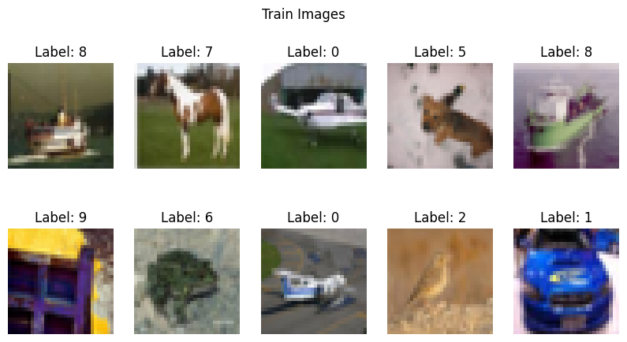

```python
# Извлекаем 10 изображений и меток из тренировочного набора
train_images, train_labels = next(iter(train_loader))
train_images, train_labels = train_images[:10], train_labels[:10]

# Выводим тренировочные изображения
show_images(train_images, train_labels, title="Train Images")
```

**0:** plane; **1:** car; **2:** bird; **3:** cat; **4:** deer; **5:** dog; **6:** frog; **7:** horse; **8:** ship; **9:** truck

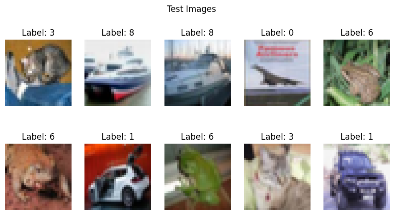

```python
# Извлекаем 10 изображений и меток из тестового набора
test_images, test_labels = next(iter(test_loader))
test_images, test_labels = test_images[:10], test_labels[:10]

# Выводим тестовые изображения
show_images(test_images, test_labels, title="Test Images")
```

### 3️⃣ Уникальные метки

```python
# Подсчет уникальных меток
unique_labels = set(train_dataset.targets)
num_unique_labels = len(unique_labels)
print(f"Train: количество уникальных меток: {num_unique_labels}")
```

```
Train: количество уникальных меток: 10
```

```python
# 'plane', 'car', 'bird', 'cat', 'deer', 'dog', 'frog', 'horse', 'ship', 'truck'
unique_counts = Counter(train_dataset.targets)
sorted_counts = sorted(unique_counts.items(), key=lambda item: item[0])

print(sorted_counts)
```

```
[(0, 5000), (1, 5000), (2, 5000), (3, 5000), (4, 5000), (5, 5000), (6, 5000), (7, 5000), (8, 5000), (9, 5000)]
```

```python
# Подсчет уникальных меток
unique_labels = set(test_dataset.targets)
num_unique_labels = len(unique_labels)
print(f"Test: количество уникальных меток: {num_unique_labels}")
```

```
Test: количество уникальных меток: 10
```

```python
# 'plane', 'car', 'bird', 'cat', 'deer', 'dog', 'frog', 'horse', 'ship', 'truck'
unique_counts = Counter(test_dataset.targets)
sorted_counts = sorted(unique_counts.items(), key=lambda item: item[0])

print(sorted_counts)
```

```
[(0, 1000), (1, 1000), (2, 1000), (3, 1000), (4, 1000), (5, 1000), (6, 1000), (7, 1000), (8, 1000), (9, 1000)]
```

### 4️⃣ Значения цвета пикселей после нормализации

```python
def check_min_max(loader):
    # Инициализируем min и max значениями
    global_min = float('inf')
    global_max = float('-inf')

    # Проходим по всем батчам в loader
    for images, _ in loader:
        batch_min = images.min().item()  # Минимум в текущем батче
        batch_max = images.max().item()  # Максимум в текущем батче

        # Обновляем глобальные минимумы и максимумы
        global_min = min(global_min, batch_min)
        global_max = max(global_max, batch_max)

    return global_min, global_max
```

```python
# Проверка для тренировочного набора
train_min, train_max = check_min_max(train_loader)
print(f'Минимум и максимум для тренировочного набора: {train_min}, {train_max}')
```

```
Минимум и максимум для тренировочного набора: -1.0, 1.0
```

```python
# Проверка для тестового набора
test_min, test_max = check_min_max(test_loader)
print(f'Минимум и максимум для тестового набора: {test_min}, {test_max}')
```

```
Минимум и максимум для тестового набора: -1.0, 1.0
```

**т.к. применялась** стандартная нормализация (0.5, 0.5, 0.5)

### ✅ 4. CNN: сверточная нерйонная сеть

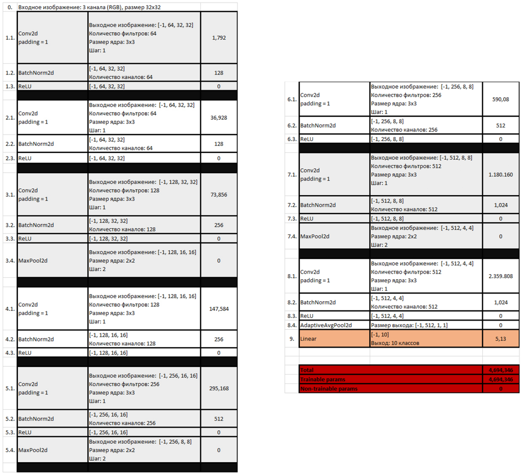

```python
show_info_abt_architecture('E:/Lab2_DL_photo/nn1.jpg', 'E:/Lab2_DL_photo/nn2.jpg')
```

**0.0.** Входное изображение $3 \cdot 32 \cdot 32$

### 1️⃣ Последовательный блок свёрточных слоев с возможным пуллингом

- **nn.Conv2d:** сверточный слой с ядром 3x3 и паддингом 1 для сохранения пространственного размера. Преобразует тензор с input_channels каналами в тензор с output_channels каналами.
- **nn.BatchNorm2d:** слой нормализации по мини-батчу для стабилизации обучения.
- **nn.ReLU():** функция активации ReLU, которая добавляет нелинейность.
- **MaxPooling** с ядром 2x2 для уменьшения размерности по высоте и ширине в 2 раза.

```python
# input_channels количество вх каналов
# output_channels количество вых каналов
# pool: если этот параметр равен True, в блок добавляется MaxPooling слой.
def conv_block(input_channels, output_channels, pool):
    layers = [nn.Conv2d(input_channels, output_channels, kernel_size = 3, padding = 1), nn.BatchNorm2d(output_channels), nn.ReLU()]

    if pool:
        layers.append(nn.MaxPool2d(2))

    # Возвращается объект nn.Sequential, содержащий созданный блок слоев.
    return nn.Sequential(*layers)
```

### 2️⃣ Класс нейронной сети, наследующийся от nn.Module

- постепенно увеличивается количество каналов, а также уменьшается размер изображения через MaxPooling
- adaptive_pool: адаптивный усредненный пулинг приводит каждую карту признаков к размеру 1x1, независимо от исходного размера входа
- self.fc полносвязный слой преобразует 512 выходных признаков в 10 выходных классов
- out = out.view(out.size(0), -1): преобразует тензор из формы (batch_size, 512, 1, 1) в (batch_size, 512), удаляя лишние пространственные размеры (1, 1).  
  Нужно для того, чтобы передать данные в полносвязный слой, который ожидает на вход вектор признаков, а не 4-мерный тензор.

```python
class SimpleCNN(nn.Module):
    # input_channels = 3: количество каналов на входе
    # output_channels = 10: количество классов для классификации
    def __init__(self, input_channels = 3, output_channels = 10):
        super(SimpleCNN, self).__init__() # конструктор родительского класса nn.Module
        self.block1 = nn.Sequential(
            conv_block(input_channels, 64, False),  # 3 канала -> 64 каналов, без пуллинга
            conv_block(64, 64, False),              # 64 канала -> 64 каналов, без пуллинга
            conv_block(64, 128, True),              # 64 канала -> 128 каналов, с пуллингом
            conv_block(128, 128, False),            # 128 -> 128, без пуллинга
            conv_block(128, 256, True),             # 128 -> 256, с пуллингом
            conv_block(256, 256, False),            # 256 -> 256, без пуллинга
            conv_block(256, 512, True),             # 256 -> 512, с пуллингом
            conv_block(512, 512, False))            # 512 -> 512, без пуллинга


        # Адаптивный пуллинг для выравнивания выходов
        self.adaptive_pool = nn.AdaptiveAvgPool2d((1, 1))

        self.fc = nn.Linear(512, output_channels)

    # метод (прямое распространение)
    def forward(self, x):
        out = self.block1(x)                # Пропуск данных через через последовательность сверточных блоков.
        out = self.adaptive_pool(out)       # Применяем адаптивный пулинг, чтобы получить карты признаков размером 1x1 для каждого канала.
        out = out.view(out.size(0), -1)     # Преобразование в вектор (batch_size, 512)
        out = self.fc(out)                  # Применение полносвязного слоя, чтобы получить выход размером (batch_size, 10)
        return out
```

### 3️⃣ Создание объекта класса SimpleCNN

- nn.CrossEntropyLoss() — это функция потерь, которая используется для задач классификации
- optim.Adam() — это оптимизатор: адаптивно регулирует скорость обучения для каждого параметра модели
- model.parameters() передаёт все параметры модели в оптимизатор для их обновления при обучении (например, веса слоёв).
- optimizer обновляет параметры модели (например, веса), чтобы минимизировать ошибку, возвращаемую функцией потерь.

```python
# объект, который указывает, на каком устройстве будут выполняться вычисления.
device = torch.device("cuda" if torch.cuda.is_available() else "cpu")
print(device)
```

```
cuda
```

```python
# Передача модели на устройство
model = SimpleCNN().to(device)

criterion = nn.CrossEntropyLoss().to(device)
optimizer = optim.Adam(model.parameters(), lr = learning_rate)
```

### 4️⃣ Обучение модели

```python
def train_one_epoch(model, train_loader, criterion, optimizer, device):
    # списки для хранения значений точности и потерь на каждой итерации батча в эпохе.
    accuracy_list = []
    loss_list = []

    # Проходим по каждому батчу данных в train_loader
    for data in train_loader:
        images = data[0].to(device)
        labels = data[1].to(device)

        # обнулить градиенты перед обновлением параметров модели
        optimizer.zero_grad()

        # Прямой проход: входные изображения пропускаются через слои модели
        u = model(images)

        # рассчитываем функцию потерь
        loss = criterion(u, labels)
        loss_list.append(loss.item())

        # Обратный проход: вычисляет градиенты потерь по отношению ко всем параметрам модели
        loss.backward()
        # Оптимизатор обновляет веса модели, используя вычисленные градиенты.
        optimizer.step()

        # torch.argmax(u, dim=1): определяем предсказанные классы, который выбирает класс с max(вероят.) для каждого изображения.
        # Сравниваем предсказания с истинными метками и вычисляем среднюю точность для данного батча.
        accuracy_list.append((torch.argmax(u, dim=1) == labels).float().mean())

    # рассчитываем средние значения потерь и точности по всем батчам в текущей эпохе
    avg_loss = torch.tensor(loss_list).mean()
    avg_accuracy = torch.tensor(accuracy_list).mean()

    return avg_loss.cpu().detach().numpy(), avg_accuracy.cpu().detach().numpy()
```

```python
graph_loss = []
graph_acc = []

for epoch in range(epochs):
    time_one = time.time()

    avg_loss, avg_accuracy = train_one_epoch(model, train_loader, criterion, optimizer, device)

    difference_time = time.time() - time_one
    print(f"Epoch: {epoch + 1}/{epochs}," f"Время работы: {difference_time:.3f}", f"Ошибка: {avg_loss:.6f}," f"Точность: {avg_accuracy:.6f}")

    # Добавляем значения потерь и точности в графики
    graph_loss.append(avg_loss)
    graph_acc.append(avg_accuracy)
```

```
Epoch: 1/20,Время работы: 25.375 Ошибка: 1.161843,Точность: 0.579064
Epoch: 2/20,Время работы: 24.936 Ошибка: 0.708978,Точность: 0.752198
Epoch: 3/20,Время работы: 24.881 Ошибка: 0.536239,Точность: 0.813479
Epoch: 4/20,Время работы: 24.939 Ошибка: 0.418252,Точность: 0.855039
Epoch: 5/20,Время работы: 24.969 Ошибка: 0.339082,Точность: 0.882393
Epoch: 6/20,Время работы: 24.913 Ошибка: 0.258490,Точность: 0.910106
Epoch: 7/20,Время работы: 24.902 Ошибка: 0.202527,Точность: 0.928009
Epoch: 8/20,Время работы: 24.997 Ошибка: 0.152695,Точность: 0.946531
Epoch: 9/20,Время работы: 24.984 Ошибка: 0.109876,Точность: 0.960938
Epoch: 10/20,Время работы: 25.095 Ошибка: 0.088182,Точность: 0.969130
Epoch: 11/20,Время работы: 25.035 Ошибка: 0.072366,Точность: 0.974584
Epoch: 12/20,Время работы: 25.182 Ошибка: 0.061494,Точность: 0.978241
Epoch: 13/20,Время работы: 24.975 Ошибка: 0.054640,Точность: 0.980978
Epoch: 14/20,Время работы: 24.961 Ошибка: 0.049592,Точность: 0.982836
Epoch: 15/20,Время работы: 25.009 Ошибка: 0.040951,Точность: 0.986133
Epoch: 16/20,Время работы: 25.047 Ошибка: 0.044663,Точность: 0.984375
Epoch: 17/20,Время работы: 25.049 Ошибка: 0.036286,Точность: 0.988032
Epoch: 18/20,Время работы: 25.027 Ошибка: 0.029716,Точность: 0.989710
Epoch: 19/20,Время работы: 25.028 Ошибка: 0.037030,Точность: 0.987072
Epoch: 20/20,Время работы: 25.043 Ошибка: 0.029624,Точность: 0.989810
```

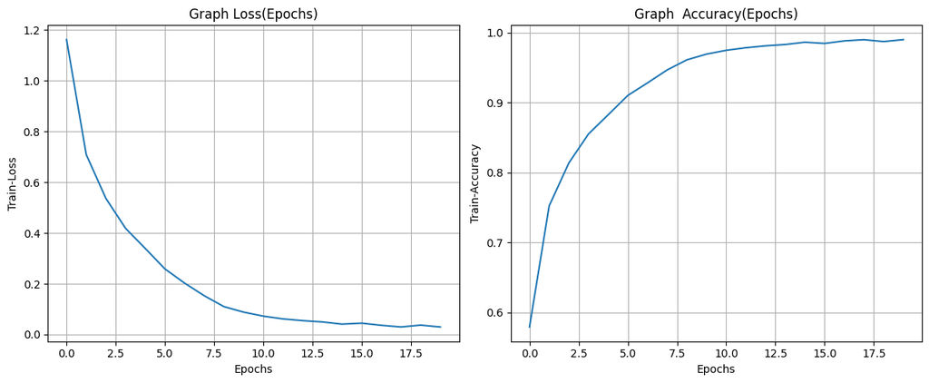

```python
fig, (ax1, ax2) = plt.subplots(1, 2, figsize=(12, 5))

ax1.plot(graph_loss)
ax1.set_xlabel('Epochs')
ax1.set_ylabel('Train-Loss')
ax1.set_title('Graph Loss(Epochs)')
ax1.grid(True)

ax2.plot(graph_acc)
ax2.set_xlabel('Epochs')
ax2.set_ylabel('Train-Accuracy')
ax2.set_title('Graph  Accuracy(Epochs)')
ax2.grid(True)

plt.tight_layout()
plt.show()
```

### 5️⃣ Тестирование модели

```python
# Функция для тестирования модели
def test(data_loader):
    loss, accuracy, cur_total = 0, 0, 0

    # Отключение вычисления градиентов: так как на этапе тестирования градиенты не нужны
    with torch.no_grad():
        # Итерация по всем данным в тестовом загрузчике
        for data in data_loader:
            images = data[0].to(device)
            labels = data[1].to(device)

            # Прямой проход
            u = model(images)

            # Вычисление поетрь
            loss += criterion(u, labels).item()
            # Увеличиваем счётчик n на количество данных в текущей партии
            cur_total += labels.size(0)

            # Получение предсказанных меток: для каждого изображения выбираем индекс с наибольшим значением вероятности
            _, predicted_labels = torch.max(u.data, 1)

            # Подсчёт правильных предсказаний
            accuracy += (predicted_labels == labels).sum().item()

    print(f"Test loss: {loss / cur_total:.4f}, Test accuracy: {accuracy / cur_total:.4f}")
```

```python
test(test_loader)
```

```
Test loss: 0.0109, Test accuracy: 0.8675
```